# Fertilität in der BRD

Henrik-Alexander Schubert, Steffen Peters

2025-08-27

# 1 Was ist die Geburtenrate?

Die allgemeine Geburtenziffer (TFR) gibt an, *wie viele Kinder eine Frau im Durchschnitt bekäme, wenn sie dem Geburtengeschehen aus einem spezifischen Jahr folgte.* Diese Zahl wird auch als synthetische Maßzahl bezeichnet, wie der Konjunktiv verdeutlicht, weil die Geburtenraten aus einem Jahr genutzt werden als würden sie sich über das Leben erstrecken. Demografen sprechen von einer Periodenzahl, welche sich auf ein Kalenderjahr bezieht. Diese Maße unterscheiden sich von Kohortenmaßen, welche sich auf die Geburtenzahlen am Ende der reproduktiven Phase einer Gruppe beziehen, also das gelebte Geburtengeschehen von einem Geburtsjahrgang. Periodenraten werden genutzt, weil sie das aktuelle Geschehen besser reflektieren, denn für die Kohortenmaße müsste man stets warten bis die reproduktive Phase vollständig abgeschlossen ist, also bis ein Geburtsjahrgang z.B. das Alter 50 erreicht hat.

Periodenmaße haben einen großen Nachteil: Periodenmaße sind sehr sensitiv für Geburtenaufschübe und vorgezogene Geburten. Das liegt daran, dass Geburtenverschiebungen in den Periodenmaßen erscheinen wie Reduktionen der Geburten, aber in Wirklichkeit können Frauen die gleiche Anzahl an Geburten im Leben haben (nur eben später). Deswegen sind kurzfristige Abfälle der TFR noch nicht unbedingt ein Zeichen für weniger Geburten, gleichermaßen kann es sich lediglich um einen zeitweisen Aufschub handeln.

# 2 Wie sieht die Entwicklung der Geburtenrate aus?

Die Entwicklung der Geburtenrate ist einer ständigen Fluktuation unterworfen, wobei das Niveau seit einigen Jahrzehnten relativ konstant zwischen 1.3 und 1.6 Kindern pro Frau liegt. In den 1960er Jahren lagen die Geburtenraten auf einem hohen Niveau aufgrund des sogennanten Babybooms, z.B. in Jahr 1965 bei 2.501. Zwischen 1975 und 2010 war die Geburtenrate relativ stabil auf einem niedrigem Niveau, wie die schwarze Linie in Grafik 2.1 verdeutlicht. In der BRD schwankte die TFR zwischen 1.249 und 1.561. Dieses Niveau ist niedriger als 2.1, das sogenannte Selbsterhaltungsniveau, sodass die BRD bereits seit den frühen 1970ern schrumpfen würde, sofern es keine positive Nettomigration gäbe. Jedoch, wischen 2010 und 2021 stieg die TFR wieder von 1.42 auf 1.57 (für 2017), siehe auch Grafik 2.2.

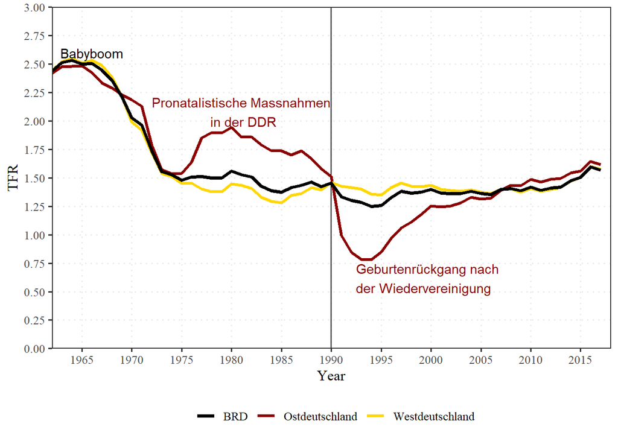

Figure 2.1: Trend in den allgemeinen Geburtenraten

Für den Zeitraum zwischen 2012 und 2025 gibt es sogar monatliche Geburtenraten, die in Grafik 2.2 dargestellt sind. Dieser Zeitraum lässt sich grob in drei abschnitte Unterteilen:

1. 2012-2018: Anstieg der Geburtenrate
2. 2018-2021: Stagnierende Geburtenraten
3. 2021-2025: Rückgang der Geburtenraten

Der Rückgang in den letzten Jahren auf ein Niveau um die 1.35 Kinder pro Frau ist ein niedriger Wert für die Bundrepublik, aber in den frühen 1990er Jahren lag die TFR ebenfalls unter 1.35. So lag die TFR in 1994 bei 1.249. Somit ist das aktuelle Niveau kein Tiefstwert.

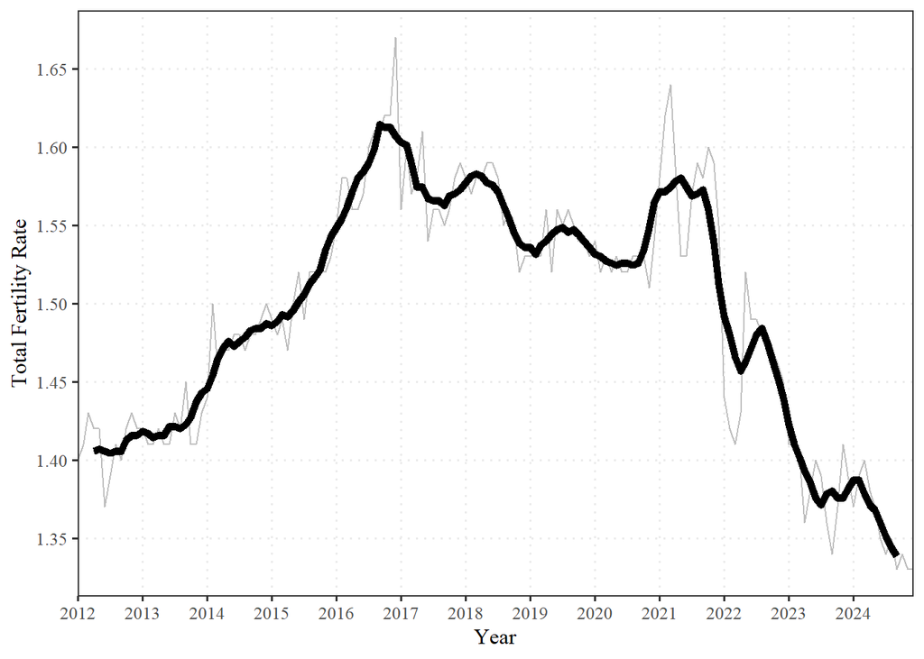

Figure 2.2: Trend in the monthly seasonally-adjsuted total fertility rate. Source: Short-Term Fertility Fluctuations.

# 3 Fragen und Antworten

> 1. Welche Hauptursachen sehen Sie für den derzeit zu beobachtenden Rückgang der Geburtenrate in Deutschland?

Der Geburtenrückgang seit 2021 ist vermutlich eine Mischung aus einer Reduktion an Geburten und einem Geburtenaufschub. Zumindest verweist die zeitliche Überschneidung mit der Coronapandemie auf eine wachsende Verunsicherung hin. Leider gibt es für den Zeitraum noch keine Altersspezifische Geburtenraten, aber es lässt sich vermuten basierend auf Ergebnissen aus anderen Ländern, dass der letzte Rückgang der Geburtenraten eine Mischung aus weniger Geburten und einem Geburtenaufschub ist. Bujard and Andersson (2024) finden, dass der Geburtenrückgang nicht mit ökonomischen oder gesundheitlichen Entwicklungen korreliert, aber mit dem Ausrollen von Impfkampanien. Die Autoren spekulieren, dass Paare das Kinderkriegen temporär aufgeschoben haben, um zuerst noch eine Corona-Schutzimpfung zu sichern. Jedoch diskutieren die Autoren ebenfalls, ob die stressige Zeit sowie die ökonomischen Auswirkungen der Pandemie und des Ukrainekriegs eventuell den Aufschub verstetigen und zu weniger Geburten führen. Es lässt sich aktuell noch nicht final beantworten, ob die aufgeschobenen Geburten zu einem späteren Zeitpunkt noch nachgeholt werden. Jedenfalls deutet der anhaltende Geburtenrückgang, zwischen 2021 und 2025 auf einen tatsächlichen Rückgang der Geburten hin. Jedoch hebt das Statistisches Bundesamt (2025) hervor, dass sich der Geburtenrückgang bereits abschwächt, und in 2024 nur noch 2% betrug, im Vergleich zu den 7% und 9% Rückgang aus den Vorjahren.

> 2. In welchem Maße wirken sich wirtschaftliche und soziale Faktoren – etwa Kinderbetreuungskosten oder Erwerbsbeteiligung der Eltern – auf die Familienplanung aus?

Wirtschaftliche und soziale Faktoren spielen eine wichtige Rolle für die Geburtenraten. Durch die breite Verfügbarkeit von effizienten Verhütungsmitteln lässt sich die Reproduktion zuverlässig kontrollieren, sodass strukturelle und normative Faktoren eine große Rolle für kurzfristige Entwicklungen spielen.

Die wirtschaftliche Situation beeinflusst das Geburtenverhalten hauptsächlich auf zwei Wege, siehe zu einem generellen Überblick Sobotka, Skirbekk, and Philipov (2011):

1. Durch den *direkten Einfluss* auf die Arbeitslosigkeit und das Einkommen beeinflusst die wirtschaftliche Situation die Ressourcen eines Paares für ein Kind zu sorgen.
2. Durch einen *indirekten Einfluss* auf das Gefühl der Absicherung und Planbarkeit in der Zukunft.

Die institutionelle Kinderbetreuung spielt eine zunehmend wichtigere Rolle, weil das Bildungsniveau und die Arbeitsbeteiligung von Frauen seit den 1970ern stetig angestiegen ist. Im ersten Schritt hat die ansteigende Erwerbsbeteiligung von Frauen einen Konflikt zwischen Familie und Arbeit verstärkt, was von Goldscheider, Bernhardt, and Lappegård (2015) als erste Phase der Gender Revolution theoresiert wurde. Dieser Konflikt kann aber potentiell durch staatliche oder familiäre Akteure neutralisiert werden. Der staatliche Akteur kann beispielsweise preiswerte, verfügbare, erreichbare und ausreichende Kindertagestätten zur Verfügung stellen, sodass sich die Zeit- und Aufgabenkonflikte der Müttererwerbstätigkeit minimieren. Alternativ kann die Familie unterstützen, indem zum Beispiel die Väter einen größeren Betreuungsanteil übernehmen. BMBFSFJ (2021) zeigt zumindest, dass Väter gerne mehr Zeit mit den Kindern verbringen würden.

> 3. Welche Rolle spielen kulturelle Normen, Wertvorstellungen und Lebensstile bei der Entscheidung für oder gegen Kinder?

Kulturelle Faktoren sind ebenfalls von großer Bedeutung, jedoch lässt sich hinterfragen, ob langsame kulturelle Entwicklungen einen so abrupten und starken Abfall der Geburtenrate erklären könnten, zumal kulturelle Normen schwieriger zu messen sind als Wertevorstellungen oder Indikatoren von Lebensstilen. Wir würden zumindest argumentieren, dass kulturelle Entwicklungen nicht alleine verantwortlich sein können, weil der Abfall dann langsamer und länger fortschreiten würde. Hinsichtlich der kulturellen Faktoren steht vor Allem die Theorie des zweiten demografischen Übergangs von van de Kaa (1987) und Lesthaeghe and Surkyn (1988) im Zentrum der Diskussion. Diese Theorie sieht die Individualisierung als wichtigen Erklärungsfaktor von Geburten- und Familienentwicklungen. So verstärkt die Individualisierung den Fokus auf sich selbst, reduziert den Einfluss von Familiennormen, führt zu einer Pluralisierung der Familienformen und führt zu anderen Lebenszielen und Selbstverwirklichungen. Diese Entwicklungen führen zu einer Verschiebung des Fokus von den Kindern auf die Eltern, zu einem Geburtenaufschub in spätere Lebensjahre, in denen die biologische Fruchtbarkeit abnimmt, Destabilisierung von Partnerschaften, und dass Alternativen zur traditionellen Ehegemeinschaft in der Gessellschaft relevanter werden. Kearney, Levine, and Pardue (2022) argumentieren zum Beispiel, dass diese Theorie am besten den Geburtenrückgang in den USA erklären könnte.

> 4. Welche politischen oder gesellschaftlichen Maßnahmen erachten Sie als besonders wirksam, um dem negativen Trend entgegenzusteuern und wie lassen sich Erfolge oder Misserfolge dieser Initiativen Ihrer Meinung nach am besten messen?

Politische Maßnahmen haben in der Vergangenheit oft nur begrenzten Einfluss auf die Geburtenrate gehabt, und meistens führten die Maßnahmen nur dazu, dass Kinder vorgezogen wurden, aber nicht mehr Kinder geboren worden sind (Gietel-Basten, Rotkirch, and Sobotka 2022). Ungarn, Japan, Südkorea, und Russland sind aktuelle Beispiele, welche bereits pronatalistische Maßnahmen eingeführt haben, die bisher keine nennenswerten Auswirkungen auf die Geburtenraten hatten. Eine aktuelle Stellungnahme von führenden Fertilitätsforschern schlussfolgert deswegen: “*Such policy responses have questionable justifications, limited effect on fertility, and potentially harmful effects on sexual and reproductive health, human rights, and gender equality.*” (p. 1, Gietel-Basten, Rotkirch, and Sobotka 2022)

Politische und gesellschaftliche Maßnahmen können potentiell darauf abzielen, dass Erwachsene mehr Kinder haben wollen (Fertilitätsabsichten) oder das Paare ihre Fertilitätsabsichten besser realisieren (Fertilitätsverhalten). Kulturelle Entwicklungen zu einer verstärkten Individualisierung stehen dem ersten Ziel entgegen. Das zweite Ziel birgt deswegen mehr Potential. Politische und gesellschaftliche Maßnahmen könnten effizienter sein und die Geburtenzahlen erhöhen, wenn die Menschen ihre Fertilitätsabsichten besser realisieren könnten. Aktuelle Forschung hat gezeigt, dass in Deutschland, wie in vielen anderen Ländern, die gewünschte Fertilität höher liegt als die realisierte (d.h. die Menschen wollen mehr Kinder als sie tatsächlich bekommen) (Beaujouan and Berghammer 2019). Solche Maßnahmen könnten gezielt die Unsicherheit der Menschen reduzieren, da oftmals besonders unsichere Zeiten mit Geburtenrückgängen verbunden sind, z.B. in der Wendezeit in Ostdeutschland (siehe Grafik 2.1). Potentielle Ansätze in der BRD wären: flexible Arbeitszeiten für Mütter und Väter, flexible und lange Öffnungszeiten von Kindertagesstätten, und flexible Unterstützungen für die Herausforderungen von jungen Familien zu schaffen (Bergsvik, Fauske, and Hart 2021). Deswegen lässt sich Schlussfolgern: “*Adopting a person centred, inclusive, rights based, and gender sensitive approach to fertility, following principles set out at the 1994 International Conference of Population and Development is more likely to deliver a sustainable response to low fertility.*” (p. 1, Gietel-Basten, Rotkirch, and Sobotka 2022).

> 5. Wie beurteilen Sie die langfristigen wirtschaftlichen und gesellschaftlichen Folgen einer dauerhaft niedrigen Geburtenrate?

Die langfristigen Bevölkerungsentwicklungen sind nicht ganz eindeutig abzuschätzen, weil es sehr stark darauf ankommt, wie die Gesellschaft auf die niedrigen und fallenden Geburtenraten reagiert. Im Zug der Alterung der Gesellschaft gibt es drohende Herausforderungen im Bereich des Arbeitsmarktes und des Rentensystems, aber diese können mit einer vorausschauenende Politk gemeistert werden. Außerdem können niedrige Geburtenrate positive Auswirkungen auf das Klima, die Wohnungsmärkte in Ballungszentren und Chancen auf dem Arbeitsmarkt für junge Leute haben.

- **Schrumpfen und Alterung der Gesellschaft:** Seit 1972 gibt es mehr Sterbefälle in Deutschland als Geburten, also würde die deutsche Bevölkerung bereits seit über 50 Jahren schrumpfen, wenn es keine Nettomigration gäbe. Jedoch ist die Bevölkerung im gleichen Zeitraum kontinuierlich gewachsen, ausgenommen von den zwei Coronajahren. Somit bedeutet eine niedrige Geburtenrate nicht zwangsläufig eine schrumpfende Gesellschaft. Ein Gegenbeispiel dazu ist Japan, wo aufgrund der Insellage und der kulturellen Eigenart die Immigration sehr gering ist und nicht den Bevölkerungsrückgang aufhalten kann. Japan ist auch eines der ältesten Länder der Welt, was auf die niedrigen Geburtenrate und die hohen Lebenserwartung zurückzuführen ist. Die niedrige Geburtenraten sind der Hauptgrund für die Alterung der Bevölkerung (Lee and Zhou 2017). Jedoch ist Japan trotz Alterung und Bevölkerungsrückgang eine funktionierende Gesellschaft. Die Herausforderungen in der Pflege und auf dem Arbeitsmarkt werden dort durch neue Technologien gelöst.
- **Rente:** Das deutsche Rentensystem baut auf dem Umlageprinzip auf, das bedeutet, dass die Arbeitnehmer die Gelder einzahlen welche an die aktuellen Rentner ausgezahlt werden. Dieses System ist seit mehreren Dekaden nicht mehr finanzierbar, weil nicht genügend Leute einzahlen um alle Rentner zu finanzieren, sodass das Rentensystem aus dem Bundeshaushalt (Steuermitteln) bezuschusst wird. Niedrige und fallende Geburtenraten tragen zu der finanziellen Schieflage im Rentensystem bei, weil sie das Verhältnis der EinzahlerInnen zu den EmpfängerInnen reduziert. Die Rentendebatte ist deswegen stark mit der Debatte um Geburtenraten verknüpft. Jedoch ist das Bild einerseits unvollständig, weil es neben der Rente andere Transferleistungen gibt, wie z.B. Betreuung von Kindern durch Großeltern etc., welche positive Nebenwirkungen der Alterung der Bevölkerung sind (Lee et al. 2014). Außerdem kann das Verhältnis von Einzahlern zu Empfängern auch durch nicht-demografische politische Maßnahmen verändert werden. Z.B. zahlen Beamte und Beamte nicht in die Rentenkasse ein, sondern erhalten ihre Pension ausschließlich aus Steuermitteln. Wenn diese Ausnahmeregelung geändert würde, dann würde sich das Verhältnis bereits verschieben. Alternativ könnte das Renteneinstiegsalter an die Lebenserwartung angepasst werden, wie es z.B. in Dänemark gemacht wurde. Einerseits lässt sich ein solcher Schritt durch die gesündere Bevölkerung und höhere Lebenserwartung begründen, andererseits gibt es Berufe die hohe körperliche Anforderungen besitzen und/oder soziale Gruppen, die nicht gleichermaßen länger leben (Shi and Kolk 2022). Um diesen Konflikt aufzuheben könnte man das Renteneintrittsalter an die Lebenserwartung der jeweiligen Berufsgruppe knüpfen, d.h. wenn HochschullehrerInnen eine Lebenserwartung von 90 Jahren haben, dann gehen sie später in Rente als KrankenpflegerInnen, die eine niedrige Lebenserwartung haben. Jedoch bräuchte man hierfür die passenden Daten.
- **Wirtschaftsleistung:** Eine Befürchtung ist, dass eine alternde Gesellschaft weniger produktiv ist und deswegen stagnieren und letztendlich verarmen könnte. Die Argumentation beruht auf dem Lebenszyklus der Produktivität, wonach Menschen in jungen und späten Jahren vor allem konsumieren, aber wenig produzieren, und ausschließlich zwischen 20 und 70 produktiv zur Gesellschaft beitragen (Lee et al. 2014). Jedoch hat sich das Lebenszyklusmodell als verkürzt herausgestellt. Erstens, kann der produzierende Mittelbau der Alterspyramide produktiver arbeiten, und somit die sinkende Quantität durch Qualität kompensieren. Hierfür ist vor Allem die Ausbildung der jungen Leute von großer Bedeutung (Myrskylä et al. 2024). Außerdem kann man bis ins hohe Alter sehr wohl kreativ und produktiv arbeiten, besonders wenn man gesund bleibt. Deswegen wird die Gesundheitsprophylaxe von großer Bedeutung für die zukünftige Wirtschaftskraft sein.
- **Positive Auswirkungen:** Eine alternde Gesellschaft ist zuvorderst ein Erfolg, denn sie bedeutet, dass Menschen länger und meistens auch gesünder leben. Eine Gesellschaft mit weniger Kindern kann neben den Herausforderungen auch positive Auswirkungen haben. So können in die einzelnen Kinder mehr Zeit, Ressourcen und Geld investiert werden, weil es anteilig weniger sind. Außerdem können sinkende Geburtenraten einen Beitrag zu der Verhinderung des Klimawandels leisten. Abschließend können kleine Jahrgänge den Druck von den urbanen Wohnungsmärkten nehmen. Eine Diskussion von den positiven Seiten von sinkenden Geburtenraten findet sich in Skirbekk (2022).

Abschließend lässt sich festhalten, dass große Herausforderungen mit den sinkenden Geburtenraten einhergehen. Jedoch haben eine vorausschauende, evidenzbasierte und solidarische Politik und Wirtschaft die Möglichkeit diese Herausforderungen zu lösen. In anderen Worten, die Demografie ist KEIN Schicksal. Außerdem gibt es einige positive Nebenwirkungen.

> 6. Können Sie uns aktuelle Studien, Statistiken oder Fachpublikationen empfehlen, die Ihre Einschätzungen untermauern?

Anbei finden Sie eine Liste mit aktuellen und hoch-qualitativen Studien zu Geburtenentwicklungen in der Bundesrepublik Deutschland, sowie Studien zu anderen Ländern, die unsere Argumentation unterstützen.

# Referenzen

Beaujouan, Eva, and Caroline Berghammer. 2019. “The Gap Between Lifetime Fertility Intentions and Completed Fertility in Europe and the United States: A Cohort Approach.” *Population Research and Policy Review* 38 (4): 507–35. https://doi.org/10.1007/s11113-019-09516-3.

Bergsvik, Janna, Agnes Fauske, and Rannveig Kaldager Hart. 2021. “Can Policies Stall the Fertility Fall A Systematic Review of the Quasi.” *Population and Development Review* 47 (4).

BMBFSFJ. 2021. “Väter wünschen sich mehr Zeit für die Kinderbetreuung.” BMBFSFJ. October 6, 2021. https://www.bmbfsfj.bund.de/bmbfsfj/aktuelles/alle-meldungen/vaeter-wuenschen-sich-mehr-zeit-fuer-die-kinderbetreuung-186186.

Bujard, M, and G Andersson. 2024. “Fertility Declines Near the End of the COVID-19 Pandemic: Evidence of the 2022 Birth Declines in Germany and Sweden.” *EUROPEAN JOURNAL OF POPULATION-REVUE EUROPEENNE DE DEMOGRAPHIE* 40 (1). https://doi.org/10.1007/s10680-023-09689-w.

Gietel-Basten, Stuart, Anna Rotkirch, and Tomáš Sobotka. 2022. “Changing the Perspective on Low Birth Rates: Why Simplistic Solutions Won’t Work.” *BMJ* 379 (November): e072670. https://doi.org/10.1136/bmj-2022-072670.

Goldscheider, Frances, Eva Bernhardt, and Trude Lappegård. 2015. “The Gender Revolution: A Framework for Understanding Changing Family and Demographic Behavior.” *Population and Development Review* 41 (2): 207–39. https://doi.org/10.1111/j.1728-4457.2015.00045.x.

Kaa, Dirk van de. 1987. “Europe’s Second Demographic Transition.” *Population Bulletin* 42 (1).

Kearney, Melissa S., Phillip B. Levine, and Luke Pardue. 2022. “The Puzzle of Falling US Birth Rates Since the Great Recession.” *Journal of Economic Perspectives* 36 (1): 151–76. https://doi.org/10.1257/jep.36.1.151.

Lee, Ronald, Andrew Mason, members of the NTA Network, Ronald Lee, Andrew Mason, Eugenia Amporfu, Chong-Bum An, et al. 2014. “Is Low Fertility Really a Problem? Population Aging, Dependency, and Consumption.” *Science* 346 (6206): 229–34. https://doi.org/10.1126/science.1250542.

Lee, Ronald, and Yi Zhou. 2017. “Does Fertility or Mortality Drive Contemporary Population Aging? The Revisionist View Revisited.” *Population and Development Review* 43 (2): 285–301. https://www.jstor.org/stable/26622894.

Lesthaeghe, Ron, and Johan Surkyn. 1988. “Cultural Dynamics and Economic Theories of Fertility Change.” *Population and Development Review* 14 (1): 1. https://doi.org/10.2307/1972499.

Myrskylä, Mikko, Julia Hellstrand, Sampo Lappo, Angelo Lorenti, Jessica Nisén, Ziwei Rao, and Heikki Tikanmäki. 2024. “Declining Fertility, Human Capital Investment, and Economic Sustainability.” MPIDR Working Paper. Rostock. 2024. https://doi.org/10.4054/MPIDR-WP-2024-002.

Shi, Jiaxin, and Martin Kolk. 2022. “How Does Mortality Contribute to Lifetime Pension Inequality? Evidence From Five Decades of Swedish Taxation Data.” *Demography* 59 (5): 1843–71.

Skirbekk, Vegard. 2022. *Decline and Prosper!: Changing Global Birth Rates and the Advantages of Fewer Children*. Cham: Springer International Publishing. https://doi.org/10.1007/978-3-030-91611-4.

Sobotka, Tomáš, Vegard Skirbekk, and Dimiter Philipov. 2011. “Economic Recession and Fertility in the Developed World.” *Population and Development Review* 37 (2): 267–306. https://doi.org/10.1111/j.1728-4457.2011.00411.x.

Statistisches Bundesamt. 2025. “Rückgang der Geburtenziffer schwächte sich 2024 deutlich ab.” Statistisches Bundesamt. July 17, 2025. https://www.destatis.de/DE/Presse/Pressemitteilungen/2025/07/PD25_259_12.html.